# lin_reg

Alina Levine

December 9, 2018

```r
library(tidyverse)
```

```r
library(ggplot2)
library(HH)
library("leaps")
```

# data cleaning

I want to fit one model where I include cancer incidence rate and one where I don’t

pct other race does not make sense bc race percentages should add up to 100 but they do not. pct_some_col18_24 lin combo of 3 other variables

```r
death_data_full = read_csv("data/Cancer_Registry.csv") %>%
  janitor::clean_names()
```

```r
death_data = read_csv("data/Cancer_Registry.csv") %>%
  janitor::clean_names() %>%
  dplyr::select(-c(avg_ann_count,avg_deaths_per_year, pct_some_col18_24, pct_other_race, binned_inc, geography))
```

# Multicollinearity

```r
cor(death_data)
```

```
##                            target_death_rate incidence_rate   med_income
## target_death_rate                1.000000000    0.449431698 -0.428614927
## incidence_rate                   0.449431698    1.000000000 -0.001036186
## med_income                      -0.428614927   -0.001036186  1.000000000
## pop_est2015                     -0.120073096    0.026912352  0.235522860
## poverty_percent                  0.429388980    0.009046252 -0.788965239
## study_per_cap                   -0.022285011    0.077282631  0.044002767
## median_age                       0.004375077    0.018089172 -0.013287743
## median_age_male                 -0.021929429   -0.014733235 -0.091662642
## median_age_female                0.012048386   -0.009105564 -0.153278401
## avg_household_size              -0.036905314   -0.118399973  0.112065314
## percent_married                 -0.266820464   -0.119524484  0.355122865
## pct_no_hs18_24                   0.088462610   -0.170762076 -0.289383120
## pct_hs18_24                      0.261975940    0.022643795 -0.190005681
## pct_bach_deg18_24               -0.287817410    0.046835423  0.492810246
## pct_hs25_over                    0.404589076    0.121724595 -0.471348267
## pct_bach_deg25_over             -0.485477318   -0.038177165  0.704928245
## pct_employed16_over                       NA             NA           NA
## pct_unemployed16_over            0.378412442    0.099979455 -0.453107661
## pct_private_coverage            -0.386065507    0.105174269  0.724174768
## pct_private_coverage_alone                NA             NA           NA
## pct_emp_priv_coverage           -0.267399428    0.149824526  0.747293549
## pct_public_coverage              0.404571656    0.046108610 -0.754821751
## pct_public_coverage_alone        0.449357576    0.040812287 -0.719756152
## pct_white                       -0.177399980   -0.014509829  0.167225441
## pct_black                        0.257023560    0.113488959 -0.270231619
## pct_asian                       -0.186331105   -0.008123427  0.425844240
## pct_married_households          -0.293325341   -0.152176321  0.446082895
## birth_rate                      -0.087406970   -0.118181288 -0.010194553
##                            pop_est2015 poverty_percent study_per_cap
## target_death_rate          -0.12007310     0.429388980  -0.022285011
## incidence_rate              0.02691235     0.009046252   0.077282631
## med_income                  0.23552286    -0.788965239   0.044002767
## pop_est2015                 1.00000000    -0.065299150   0.055721518
## poverty_percent            -0.06529915     1.000000000  -0.055652350
## study_per_cap               0.05572152    -0.055652350   1.000000000
## median_age                 -0.02521899    -0.029279996  -0.026029802
## median_age_male            -0.17660764    -0.214001049  -0.036647292
## median_age_female          -0.17793232    -0.148163541  -0.030577044
## avg_household_size          0.10994045     0.074307601  -0.004070887
```

[output cut: 293 more lines]

```
## pct_bach_deg18_24          -0.125073483
## pct_hs25_over               0.016600264
## pct_bach_deg25_over        -0.087940271
## pct_employed16_over                  NA
## pct_unemployed16_over      -0.067906273
## pct_private_coverage       -0.040436613
## pct_private_coverage_alone           NA
## pct_emp_priv_coverage      -0.093878001
## pct_public_coverage        -0.030530759
## pct_public_coverage_alone  -0.004752695
## pct_white                  -0.008958097
## pct_black                  -0.067804827
## pct_asian                  -0.061946987
## pct_married_households      0.102263300
## birth_rate                  1.000000000
```

```r
death_data = death_data %>%
  dplyr::select(-c(med_income, pct_private_coverage))

fit_full_1 = lm(target_death_rate ~., data = death_data)

vif(fit_full_1)
```

```
##             incidence_rate                pop_est2015
##                   1.242097                   1.375520
##            poverty_percent              study_per_cap
##                   6.584629                   1.034078
##                 median_age            median_age_male
##                   1.026562                   9.140085
##          median_age_female         avg_household_size
##                  10.295807                   1.334104
##            percent_married             pct_no_hs18_24
##                  11.161257                   1.615847
##                pct_hs18_24          pct_bach_deg18_24
##                   1.583475                   1.895028
##              pct_hs25_over        pct_bach_deg25_over
##                   3.361674                   5.164649
##        pct_employed16_over      pct_unemployed16_over
##                   6.497911                   2.630362
## pct_private_coverage_alone      pct_emp_priv_coverage
##                  20.138136                  10.111131
##        pct_public_coverage  pct_public_coverage_alone
##                  19.996148                  14.210460
##                  pct_white                  pct_black
##                   6.660159                   5.090256
##                  pct_asian     pct_married_households
##                   1.949850                   8.829051
##                 birth_rate
##                   1.169300
```

```r
#median_age_male, #median_age_female have high vif, I will take those out and just use median age
#percent_white and #percent_black have high vif, I will take out pct_black
#pct_married_households has high vif
#pct_employed16_over has high vif, pct_private_coverage_alone

death_data = death_data_full %>%
  dplyr::select(-c(pct_black, pct_asian, pct_employed16_over, median_age_male, median_age_female, pct_married_households, avg_ann_count,avg_deaths_per_year, pct_some_col18_24, pct_other_race, binned_inc, geography, med_income, pct_hs25_over, pct_private_coverage_alone))

fit_full_2 = lm(target_death_rate ~., data = death_data)

vif(fit_full_2)
```

```
##            incidence_rate               pop_est2015
##                  1.196176                  1.230401
##           poverty_percent             study_per_cap
##                  5.264278                  1.033735
##                median_age        avg_household_size
##                  1.017293                  1.228802
##           percent_married            pct_no_hs18_24
##                  3.153846                  1.554959
##               pct_hs18_24         pct_bach_deg18_24
##                  1.414022                  1.812186
##       pct_bach_deg25_over     pct_unemployed16_over
##                  2.753410                  2.280350
##      pct_private_coverage     pct_emp_priv_coverage
##                 14.835557                  6.926826
##       pct_public_coverage pct_public_coverage_alone
##                 10.916963                 16.560866
##                 pct_white                birth_rate
##                  2.359545                  1.122268
```

```r
#there is still high-multicollinearity among insurance variables, so I will remove
#pct_public_coverage_alone


death_data = death_data_full %>%
  dplyr::select(-c(pct_black, pct_asian, pct_employed16_over, median_age_male, median_age_female, pct_married_households, avg_ann_count,avg_deaths_per_year, pct_some_col18_24, pct_other_race, binned_inc, geography, med_income, pct_hs25_over, pct_private_coverage_alone, pct_public_coverage_alone))

fit_full_3 = lm(target_death_rate ~., data = death_data)

vif(fit_full_3)
```

```
##        incidence_rate           pop_est2015       poverty_percent
##              1.179314              1.226642              5.192947
##         study_per_cap            median_age    avg_household_size
##              1.033627              1.014621              1.206197
##       percent_married        pct_no_hs18_24           pct_hs18_24
##              3.153623              1.521170              1.409510
##     pct_bach_deg18_24   pct_bach_deg25_over pct_unemployed16_over
##              1.808790              2.730968              2.280318
##  pct_private_coverage pct_emp_priv_coverage   pct_public_coverage
##              7.159516              5.022374              3.998257
##             pct_white            birth_rate
##              2.338745              1.103323
```

```r
#will remove pct_private_coverage

death_data = death_data_full %>%
  dplyr::select(-c(pct_black, pct_asian, pct_employed16_over, median_age_male, median_age_female, pct_married_households, avg_ann_count,avg_deaths_per_year, pct_some_col18_24, pct_other_race, binned_inc, geography, med_income, pct_hs25_over, pct_private_coverage_alone, pct_public_coverage_alone, pct_private_coverage))



fit_full_4 = lm(target_death_rate ~., data = death_data)

vif(fit_full_4)
```

```
##        incidence_rate           pop_est2015       poverty_percent
##              1.165126              1.193381              4.472125
##         study_per_cap            median_age    avg_household_size
##              1.033299              1.013646              1.150656
##       percent_married        pct_no_hs18_24           pct_hs18_24
##              3.129639              1.447322              1.379277
##     pct_bach_deg18_24   pct_bach_deg25_over pct_unemployed16_over
##              1.804549              2.666673              2.219490
## pct_emp_priv_coverage   pct_public_coverage             pct_white
##              3.851527              3.988678              2.336090
##            birth_rate
##              1.101874
```

# Stepwise

```r
model = fit_full_4

step(model, direction='backward')
```

```
## Start:  AIC=18254.53
## target_death_rate ~ incidence_rate + pop_est2015 + poverty_percent +
##     study_per_cap + median_age + avg_household_size + percent_married +
##     pct_no_hs18_24 + pct_hs18_24 + pct_bach_deg18_24 + pct_bach_deg25_over +
##     pct_unemployed16_over + pct_emp_priv_coverage + pct_public_coverage +
##     pct_white + birth_rate
##
##                         Df Sum of Sq     RSS   AIC
## - pct_bach_deg18_24      1         4 1204700 18253
## - percent_married        1         6 1204702 18253
## - study_per_cap          1        50 1204746 18253
## - avg_household_size     1       110 1204806 18253
## - median_age             1       163 1204860 18253
## - pct_public_coverage    1       748 1205444 18254
## <none>                               1204696 18255
## - pct_no_hs18_24         1      1833 1206529 18257
## - pct_white              1      1991 1206687 18258
## - pop_est2015            1      2061 1206757 18258
## - pct_emp_priv_coverage  1      2946 1207642 18260
## - pct_unemployed16_over  1      3904 1208600 18262
## - birth_rate             1      6693 1211390 18269
## - pct_hs18_24            1     20932 1225628 18305
## - poverty_percent        1     25181 1229877 18316
## - pct_bach_deg25_over    1     82138 1286835 18454
## - incidence_rate         1    325995 1530691 18982
##
## Step:  AIC=18252.54
## target_death_rate ~ incidence_rate + pop_est2015 + poverty_percent +
##     study_per_cap + median_age + avg_household_size + percent_married +
##     pct_no_hs18_24 + pct_hs18_24 + pct_bach_deg25_over + pct_unemployed16_over +
##     pct_emp_priv_coverage + pct_public_coverage + pct_white +
##     birth_rate
##
##                         Df Sum of Sq     RSS   AIC
## - percent_married        1         6 1204706 18251
## - study_per_cap          1        49 1204750 18251
## - avg_household_size     1       108 1204809 18251
## - median_age             1       163 1204864 18251
## - pct_public_coverage    1       744 1205444 18252
## <none>                               1204700 18253
```

[output cut: 82 more lines]

```
##     birth_rate
##
##                         Df Sum of Sq     RSS   AIC
## <none>                               1205021 18245
## - pct_public_coverage    1       880 1205901 18246
## - pct_no_hs18_24         1      1953 1206974 18248
## - pop_est2015            1      2179 1207200 18249
## - pct_white              1      2617 1207638 18250
## - pct_emp_priv_coverage  1      3186 1208207 18251
## - pct_unemployed16_over  1      3923 1208944 18253
## - birth_rate             1      7022 1212043 18261
## - pct_hs18_24            1     22254 1227275 18299
## - poverty_percent        1     33894 1238915 18328
## - pct_bach_deg25_over    1     91786 1296807 18467
## - incidence_rate         1    332814 1537835 18986
```

```
##
## Call:
## lm(formula = target_death_rate ~ incidence_rate + pop_est2015 +
##     poverty_percent + pct_no_hs18_24 + pct_hs18_24 + pct_bach_deg25_over +
##     pct_unemployed16_over + pct_emp_priv_coverage + pct_public_coverage +
##     pct_white + birth_rate, data = death_data)
##
## Coefficients:
##           (Intercept)         incidence_rate            pop_est2015
##             7.600e+01              2.049e-01             -2.781e-06
##       poverty_percent         pct_no_hs18_24            pct_hs18_24
##             9.572e-01             -1.162e-01              3.374e-01
##   pct_bach_deg25_over  pct_unemployed16_over  pct_emp_priv_coverage
##            -1.575e+00              4.776e-01              2.064e-01
##   pct_public_coverage              pct_white             birth_rate
##             1.329e-01             -7.671e-02             -7.925e-01
```

```r
summary(model)
```

```
##
## Call:
## lm(formula = target_death_rate ~ ., data = death_data)
##
## Residuals:
##     Min      1Q  Median      3Q     Max
## -111.98  -11.39   -0.15   11.13  137.67
##
## Coefficients:
##                         Estimate Std. Error t value Pr(>|t|)
## (Intercept)            7.828e+01  1.014e+01   7.718 1.59e-14 ***
## incidence_rate         2.047e-01  7.148e-03  28.634  < 2e-16 ***
## pop_est2015           -2.731e-06  1.199e-06  -2.277  0.02287 *
## poverty_percent        9.487e-01  1.192e-01   7.958 2.44e-15 ***
## study_per_cap         -2.464e-04  6.934e-04  -0.355  0.72240
## median_age            -5.146e-03  8.029e-03  -0.641  0.52162
## avg_household_size    -4.748e-01  9.030e-01  -0.526  0.59910
## percent_married       -1.121e-02  9.267e-02  -0.121  0.90377
## pct_no_hs18_24        -1.153e-01  5.371e-02  -2.147  0.03185 *
## pct_hs18_24            3.394e-01  4.678e-02   7.256 5.05e-13 ***
## pct_bach_deg18_24     -1.077e-02  1.072e-01  -0.100  0.91997
## pct_bach_deg25_over   -1.572e+00  1.094e-01 -14.373  < 2e-16 ***
## pct_unemployed16_over  4.886e-01  1.559e-01   3.134  0.00174 **
## pct_emp_priv_coverage  2.043e-01  7.505e-02   2.722  0.00653 **
## pct_public_coverage    1.262e-01  9.201e-02   1.371  0.17038
## pct_white             -7.544e-02  3.371e-02  -2.238  0.02531 *
## birth_rate            -7.836e-01  1.910e-01  -4.103 4.18e-05 ***
## ---
## Signif. codes:  0 '***' 0.001 '**' 0.01 '*' 0.05 '.' 0.1 ' ' 1
##
## Residual standard error: 19.94 on 3030 degrees of freedom
## Multiple R-squared:  0.4865, Adjusted R-squared:  0.4837
## F-statistic: 179.4 on 16 and 3030 DF,  p-value: < 2.2e-16
```

variables selected are : incidence rate, pop_est2015, poverty_percent, pct_no_hs18_24, pct_hs18_24, pct_bach_deg25_over, pct_unemployed16_over, pct_emp_priv_coverage, pct_public_coverage, pct_white, birth_rate

# Criteria

```r
best <- function(model, ...)
{
  subsets <- regsubsets(formula(model), model.frame(model), ...)
  subsets <- with(summary(subsets),
                  cbind(p = as.numeric(rownames(which)), which, rss, rsq, adjr2, cp, bic))

  return(subsets)
}

View(best(model))
```

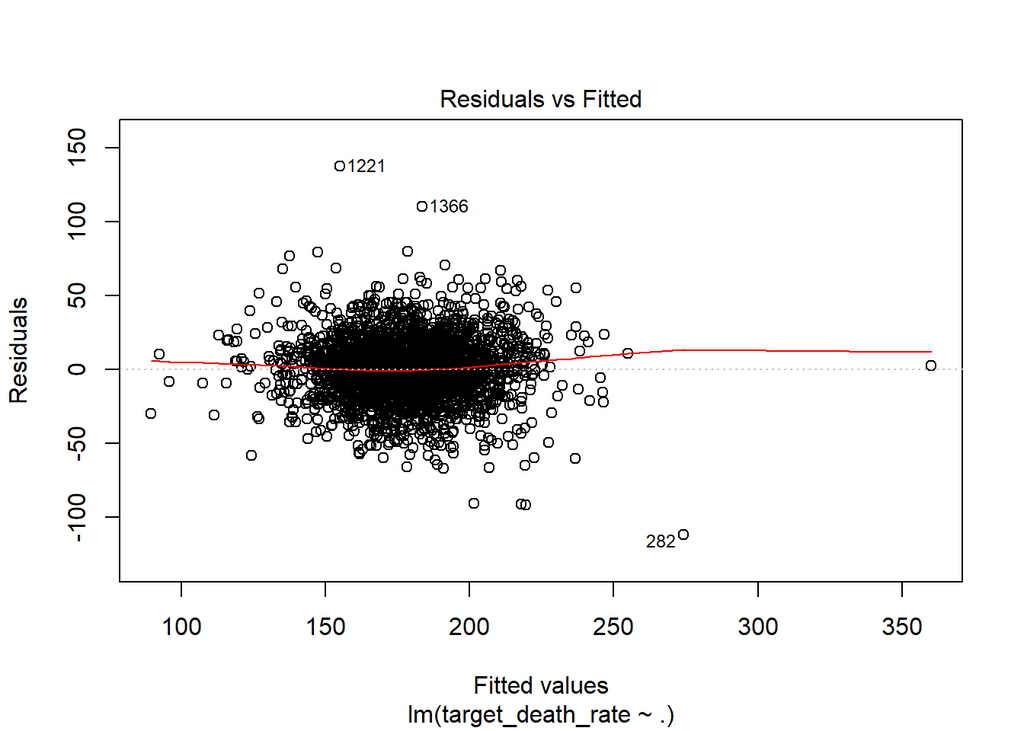

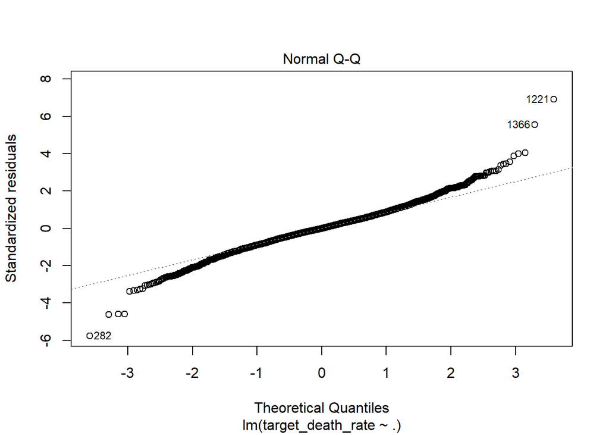

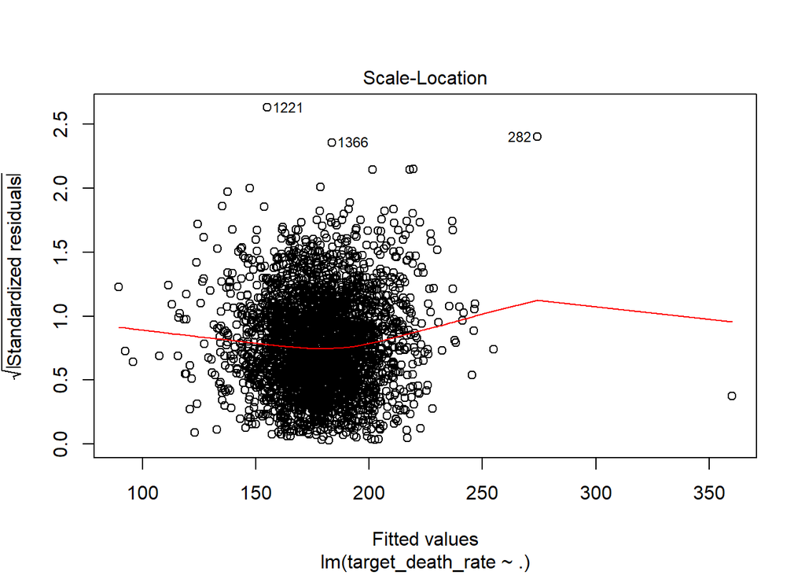

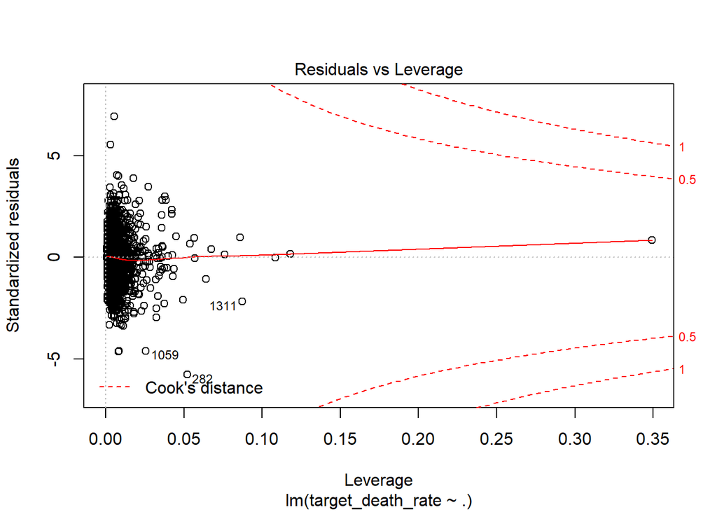

```r
plot(model)
```